# Queue Data Structure

Struktur Data Queue adalah konsep fundamental dalam ilmu komputer yang digunakan untuk menyimpan dan mengelola data dalam urutan tertentu.

- Sistem ini mengikuti prinsip " First In, First Out " (FIFO) , di mana elemen pertama yang ditambahkan ke antrian adalah elemen pertama yang dikeluarkan.
- Ini digunakan sebagai penyangga dalam sistem komputer ketika terjadi ketidaksesuaian kecepatan antara dua perangkat yang saling berkomunikasi. Misalnya, CPU dan keyboard sebagai dua perangkat dalam jaringan.
- Queue juga digunakan dalam algoritma Sistem Operasi seperti Penjadwalan CPU dan Manajemen Memori, serta banyak algoritma standar seperti Pencarian Lebar Pertama pada Graf, Penelusuran Urutan Level pada Pohon.

## Queue Introduction

Antrian (queue) adalah struktur data linier yang mengikuti Prinsip FIFO (First In First Out), sehingga elemen pertama yang dimasukkan adalah elemen pertama yang dikeluarkan.

- Ini adalah daftar terurut di mana penyisipan dilakukan di salah satu ujung yang dikenal sebagai belakang dan penghapusan dilakukan dari ujung lainnya yang dikenal sebagai depan.
- Contoh yang baik dari antrian adalah antrian konsumen untuk suatu sumber daya, di mana konsumen yang datang pertama akan dilayani terlebih dahulu.
- Perbedaan antara stack dan queue terletak pada cara menghapus elemen. Pada stack, kita menghapus elemen yang paling baru ditambahkan, sedangkan pada queue, kita menghapus elemen yang paling lama ditambahkan.

Prinsip FIFO dalam Antrian:

Prinsip FIFO menyatakan bahwa elemen pertama yang ditambahkan ke antrian akan menjadi elemen pertama yang dikeluarkan atau diproses. Jadi, antrian seperti barisan orang yang menunggu untuk membeli tiket, di mana orang pertama dalam antrian adalah orang pertama yang dilayani (yaitu, siapa cepat dia dapat).

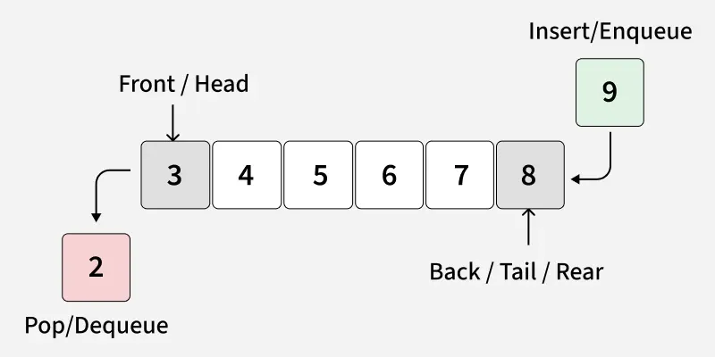

## Terminologi Dasar Antrian

- Depan: Posisi entri dalam antrian yang siap dilayani, yaitu entri pertama yang akan dikeluarkan dari antrian, disebut depan antrian. Ini juga disebut sebagai kepala antrian.
- Belakang: Posisi entri terakhir dalam antrian, yaitu yang paling baru ditambahkan, disebut belakang antrian. Ini juga disebut sebagai ekor antrian.
- Ukuran: Ukuran mengacu pada jumlah elemen yang ada dalam antrian saat ini.
- Kapasitas: Kapasitas mengacu pada jumlah maksimum elemen yang dapat ditampung oleh antrian.

## Jenis-jenis Antrian

Struktur data antrian dapat diklasifikasikan menjadi 3 jenis:

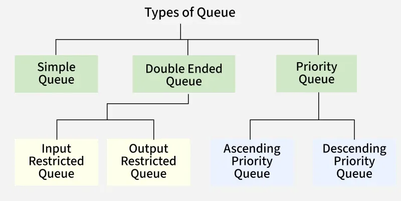

### 1. Antrian Sederhana

Antrian sederhana mengikuti prinsip FIFO (First In, First Out).

- Penyisipan hanya diperbolehkan di bagian belakang.
- Penghapusan hanya diperbolehkan dari depan.
- Dapat diimplementasikan menggunakan linked list atau circular array.
- Saat menggunakan array, kita sering lebih memilih antrian melingkar (circular queue ), yang pada dasarnya merupakan implementasi array yang efisien dari antrian sederhana. Antrian ini memanfaatkan memori secara efisien dengan menggunakan kembali ruang kosong yang tersisa setelah penghapusan, menghindari pemborosan yang terjadi pada implementasi array linier biasa.

### 2. Antrian Dua Ujung (Deque)

Dalam sebuah deque, penyisipan dan penghapusan dapat dilakukan dari kedua ujungnya.

### 3. Antrian Prioritas

Antrian di mana setiap elemen diberi prioritas , dan penghapusan selalu terjadi berdasarkan prioritas (bukan hanya posisi).

## Operasi Antrian

- Enqueue : Menambahkan elemen ke ujung (belakang) antrian. Jika antrian penuh, akan terjadi kesalahan overflow.
- Dequeue : Menghapus elemen dari bagian depan antrian. Jika antrian kosong, terjadi kesalahan underflow.
- Peek/Front : Mengembalikan elemen yang berada di depan tanpa menghapusnya.
- Ukuran : Mengembalikan jumlah elemen dalam antrian.
- isEmpty : Mengembalikan nilai true jika antrean kosong, jika tidak, mengembalikan nilai false.
- isFull : Mengembalikan nilai true jika antrean penuh, jika tidak, mengembalikan nilai false.

## Implementasi Antrian

### Queue using Array - Simple Implenmetation

Antrian adalah struktur data linier yang mengikuti prinsip FIFO (First In, First Out) . Elemen pertama yang dimasukkan adalah elemen pertama yang dikeluarkan.

Deklarasi Antrian Menggunakan Array: Antrian dapat diimplementasikan menggunakan array, dan ada dua cara utama:

- Antrian Array Tak Terbatas (atau Dapat Berkembang Secara Dinamis)
- Antrian Array Ukuran Tetap

Antrian Array Tak Terbatas (atau Dapat Berkembang Secara Dinamis): Kita dapat mengimplementasikan antrian menggunakan array yang secara konseptual tak terbatas dengan hanya mempertahankan pointer depan . Pointer depan melacak elemen valid pertama.

- Masukkan ke dalam antrean: Sisipkan pada posisi yang tersedia berikutnya di ujung. Tidak diperlukan penunjuk belakang.
- Dequeue: Menghapus elemen di depan dan menambah penunjuk depan.

Ruang sebelum front tidak pernah digunakan kembali, dan tidak seperti implementasi array dasar, kami tidak menggeser elemen setelah setiap dequeue. Hal ini memastikan operasi enqueue dan dequeue berjalan dalam waktu O(1) dengan desain yang sederhana.

Keterbatasan:

- Pemborosan ruang: Elemen-elemen sebelum penunjuk depan tidak pernah digunakan kembali, sehingga memori dapat terbuang jika banyak elemen yang dikeluarkan dari antrean.
- Asumsi array tak terbatas: Kami mengasumsikan array secara konseptual tak terbatas. Dalam praktiknya, memori terbatas, sehingga antrian yang sangat besar dapat menyebabkan masalah memori.

Antrian Array Ukuran Tetap Pada artikel ini, kita akan membahas terutama implementasi antrian menggunakan array berukuran tetap . Dalam antrian berbasis array tersebut, kita memelihara:

- Sebuah array berukuran tetap arr[] untuk menyimpan elemen-elemennya.
- Ukuran variabel untuk melacak jumlah elemen saat ini dalam antrian.
- Kapasitas variabel untuk mewakili jumlah maksimum elemen yang dapat ditampung oleh antrian.

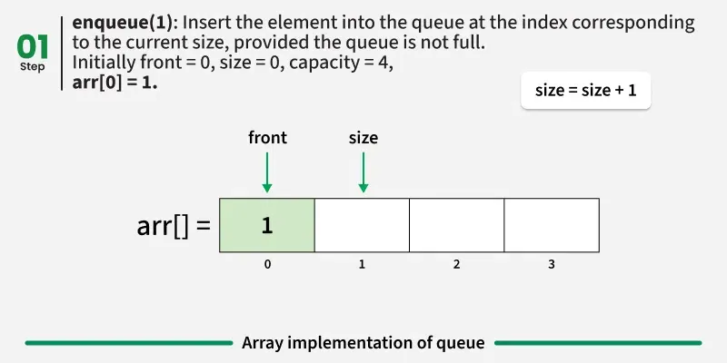

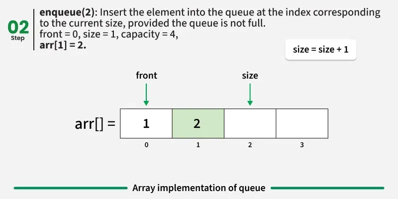

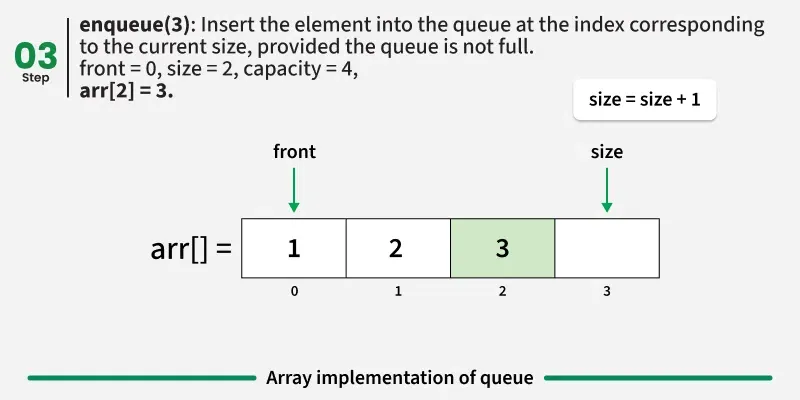

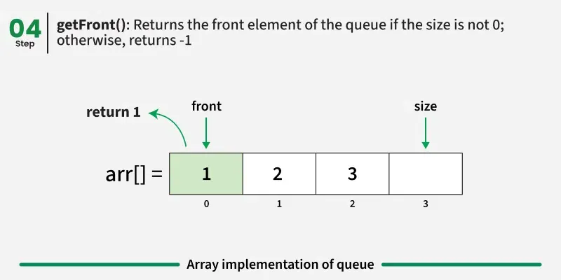

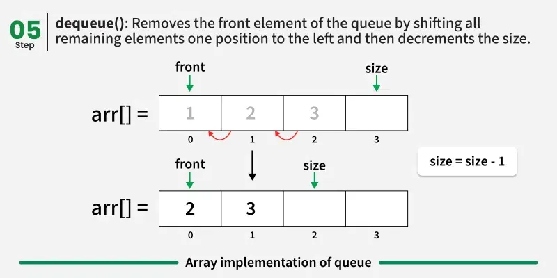

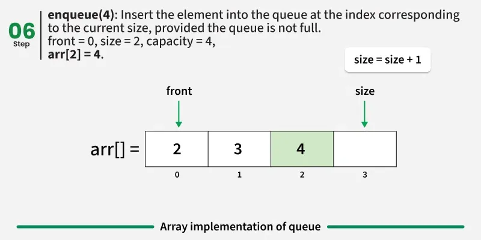

```python
class myQueue:
    def __init__(self, capacity):

        # Maximum number of elements the queue can hold.
        self.capacity = capacity

        # Array to store queue elements.
        self.arr = [0] * capacity

        # Current number of elements in the queue.
        self.size = 0
```

### Operasi pada Antrian

Masukkan ke dalam Antrean (Sisipkan):

- Tambahkan elemen di akhir antrian jika tersedia ruang; jika tidak, akan terjadi kondisi Overflow.
- Waktu: O(1), Ruang: O(1)

```python
def enqueue(self, x):
    if self.size == self.capacity:
        print("Queue Overflow")
        return

    self.arr[self.size] = x
    self.size += 1
```

Keluarkan dari antrean:

- Hapus elemen dari bagian depan antrian; jika antrian kosong, akan terjadi kondisi Underflow.
- Waktu: O(n) (karena pergeseran), Ruang: O(1)

```python
def dequeue(self):
    if self.size == 0:
        print("Queue Underflow")
        return

    for i in range(1, self.size):
        self.arr[i-1] = self.arr[i]
    self.size -= 1
```

getFront (Peek):

- Kembalikan elemen pertama jika tidak kosong, jika tidak -1.
- Waktu: O(1), Ruang: O(1)

```python
def getFront(self):
    if self.size == 0:
        print("Queue is empty")
        return -1

    return self.arr[0]
```

getRear():

- Kembalikan elemen terakhir jika tidak kosong, jika tidak -1.
- Waktu: O(1), Ruang: O(1)

```python
def getRear(self):
    if self.isEmpty():
        print("Queue is empty!")
        return -1
    return self.arr[self.size - 1]
```

isEmpty():

- Memeriksa apakah antrian memiliki elemen atau tidak.
- Mengembalikan nilai true jika antrian kosong, jika tidak, mengembalikan nilai false.
- Waktu: O(1), Ruang: O(1)

```python
def isEmpty(self):
    return self.size == 0
```

isFull():

- Memeriksa apakah antrean telah mencapai kapasitas maksimumnya.
- Mengembalikan nilai true jika antrian penuh, jika tidak, false.
- Waktu: O(1), Ruang: O(1)

```python
def isFull(self):
    return self.size == self.capacity
```

### Full Implementations of Queue using Array

```python
class myQueue:
    def __init__(self, capacity):
         #Maximum number of elements the queue can hold.
        self.capacity = capacity
        #  Array to store queue elements.
        self.arr = [0] * capacity
        #  Current number of elements in the queue.
        self.size = 0

    # Check if queue is empty
    def isEmpty(self):
        return self.size == 0

    # Check if queue is full
    def isFull(self):
        return self.size == self.capacity

    # Enqueue
    def enqueue(self, x):
        if self.isFull():
            print("Queue is full!")
            return
        self.arr[self.size] = x
        self.size += 1

    # Dequeue
    def dequeue(self):
        if self.isEmpty():
            print("Queue is empty!")
            return
        for i in range(1, self.size):
            self.arr[i - 1] = self.arr[i]
        self.size -= 1

    # Get front element
    def getFront(self):
        if self.isEmpty():
            print("Queue is empty!")
            return -1
        return self.arr[0]

    def getRear(self):
        if self.isEmpty():
           print("Queue is empty!")
           return -1
        return self.arr[self.size - 1]


# Driver code
if __name__ == '__main__':
    q = myQueue(3)

    q.enqueue(10)
    q.enqueue(20)
    q.enqueue(30)
    print("Front:", q.getFront())

    q.dequeue()
    print("Front:", q.getFront())
    print("Rear:", q.getRear())

    q.enqueue(40)
```

```
Front: 10
Front: 20
Rear: 30
```

## Implementation of Circular Queue Using Array

Antrian melingkar adalah struktur data linier yang mengatasi keterbatasan antrian sederhana. Dalam implementasi array biasa, dequeue() dapat memakan waktu O(n) atau kita mungkin membuang ruang. Dengan menggunakan array melingkar, baik enqueue() maupun dequeue() dapat dilakukan dalam waktu O(1).

Deklarasi menggunakan Array: Dalam implementasi ini, arr digunakan untuk menyimpan elemen. Beberapa variabel dikelola:

- arr[] : array untuk menyimpan elemen.
- kapasitas: ukuran maksimum antrian.
- front: indeks elemen terdepan.
- ukuran : jumlah elemen saat ini dalam antrian.

```python
class myQueue:

    def __init__(self, cap):
          # Maximum capacity of the queue
        self.capacity = cap

       # Fixed-size list to store queue elements
        self.arr = [0] * cap

       # Index of the front element
        self.front = 0

         # Current number of elements in the queue
        self.size = 0
```

### Operasi pada Antrian Melingkar:

enqueue(x) :

Tujuan: Menyisipkan elemen x di bagian belakang antrian melingkar.

- Periksa apakah antrean penuh: Jika ukuran sama dengan kapasitas, antrean penuh, cetak pesan atau kembalikan nilai.
- Hitung indeks belakang: belakang = (depan + ukuran) % kapasitas memastikan perilaku melingkar.
- Sisipkan elemen: arr[belakang] = x.
- Perbarui ukuran: Tingkatkan ukuran sebanyak 1.
- Kompleksitas Waktu: O(1) Kompleksitas Ruang: O(1) untuk array

```python
# Insert an element at the rear
def enqueue(self, x):
    if self.size == self.capacity:
        print("Queue is full!")
        return
    rear = (self.front + self.size) % self.capacity
    self.arr[rear] = x
    self.size += 1
```

dequeue() :

Tujuan: Menghapus dan mengembalikan elemen terdepan dari antrian melingkar.

- Periksa apakah antrean kosong: Jika ukuran == 0, antrean kosong, cetak pesan atau kembalikan -1.
- Ambil elemen depan: res = arr[front].
- Gerakkan bagian depan ke depan: depan = (depan + 1) % kapasitas pergerakan melingkar.
- Perbarui ukuran: Kurangi ukuran sebanyak 1.
- Elemen pengembalian: Kembalikan res.
- Kompleksitas Waktu: O(1) Kompleksitas Ruang: O(1)

```python
# Remove an element from the front
def dequeue(self):
    if self.size == 0:
        print("Queue is empty!")
        return -1
    res = self.arr[self.front]
    self.front = (self.front + 1) % self.capacity
    self.size -= 1
    return res
```

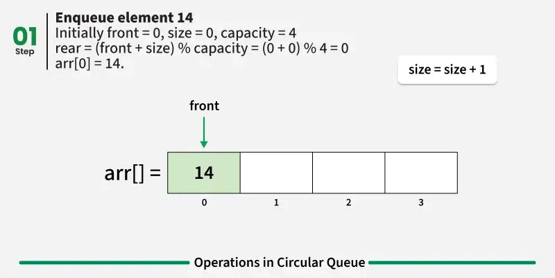

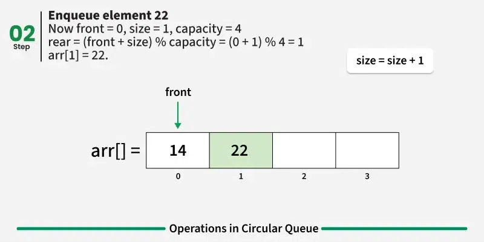

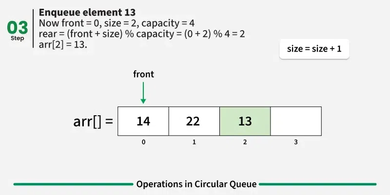

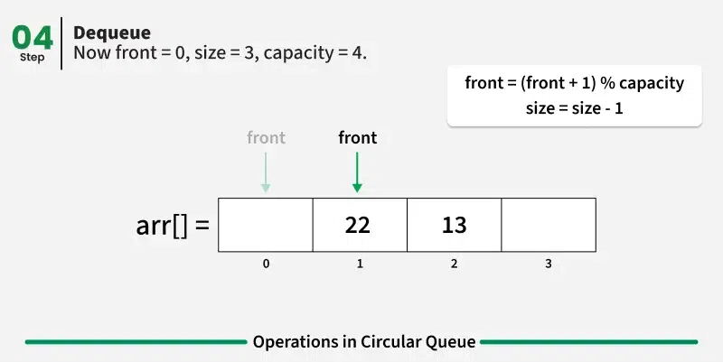

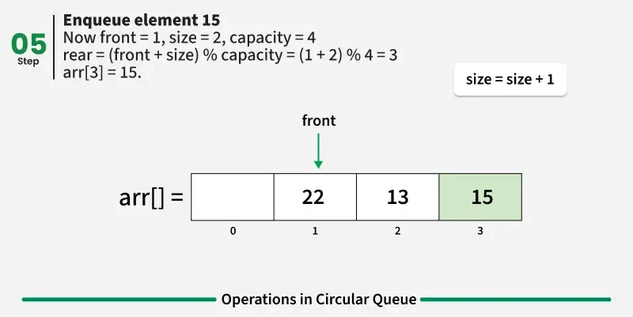

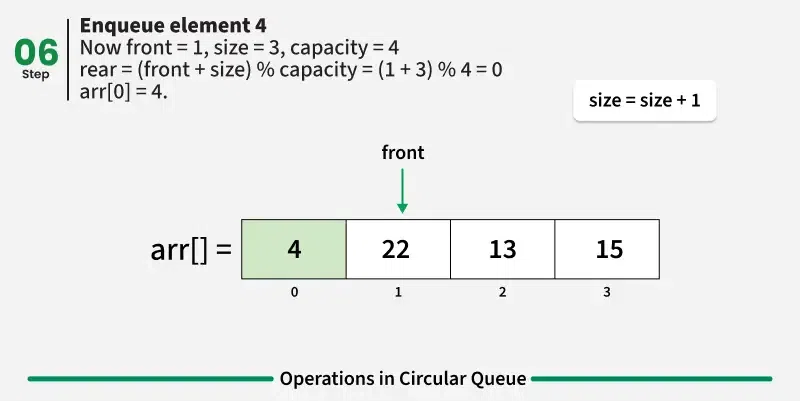

getRear() :

Tujuan: Mengembalikan elemen yang berada di bagian belakang antrian melingkar.

- Periksa apakah antrean kosong: Jika ukuran == 0, antrean kosong → kembalikan -1.
- Hitung indeks belakang: belakang = (depan + ukuran - 1) % kapasitas.
- Elemen pengembalian: Kembalikan arr[belakang].
- Kompleksitas Waktu: O(1) Kompleksitas Ruang: O(1)

```python
# Get the rear element
def getRear(self):
    if self.size == 0:
        return -1
    rear = (self.front + self.size - 1) % self.capacity
    return self.arr[rear]
```

getFront() :

Tujuan: Mengembalikan elemen yang berada di depan antrian melingkar.

- Periksa apakah antrean kosong: Jika ukuran == 0, antrean kosong → kembalikan -1.
- Elemen yang dikembalikan: arr[front] adalah elemen depan.
- Kompleksitas Waktu: O(1) Kompleksitas Ruang: O(1)

```python
# Get the front element
def getFront(self):
    if self.size == 0:
        return -1
    return self.arr[self.front]
```

#### Implementasi Lengkap:

```python
class myQueue:
    def __init__(self, cap):
         # fixed-size array
        self.arr = [0]*cap
           # index of front element
        self.front = 0
          # current number of elements
        self.size = 0
         # maximum capacity
        self.capacity = cap

    # Insert an element at the rear
    def enqueue(self, x):
        if self.size == self.capacity:
            print("Queue is full!")
            return
        rear = (self.front + self.size) % self.capacity
        self.arr[rear] = x
        self.size += 1

    # Remove an element from the front
    def dequeue(self):
        if self.size == 0:
            print("Queue is empty!")
            return -1
        res = self.arr[self.front]
        self.front = (self.front + 1) % self.capacity
        self.size -= 1
        return res

    # Get the front element
    def getFront(self):
        if self.size == 0:
            return -1
        return self.arr[self.front]

    # Get the rear element
    def getRear(self):
        if self.size == 0:
            return -1
        rear = (self.front + self.size - 1) % self.capacity
        return self.arr[rear]

if __name__ == "__main__":
    q = myQueue(5)
    q.enqueue(10)
    q.enqueue(20)
    q.enqueue(30)
    print(q.getFront(), q.getRear())
    q.dequeue()
    print(q.getFront(), q.getRear())
    q.enqueue(40)
    print(q.getFront(), q.getRear())
```

```
10 30
20 30
20 40
```